# Course Project 1: Reproducable Research

## Load and Prepare Data

Install package(s) needed

```r
library(dplyr)
library(knitr)
```

1. Load the data (i.e. read.csv())

```r
activity <- read.csv("activity.csv", header = TRUE)
```

2. Process/transform the data (if necessary) into a format suitable for your analysis

```r
activity$date <- as.Date(activity$date, '%Y-%m-%d')
```

## What is mean total number of steps taken per day?

For this part of the assignment, you can ignore the missing values in the dataset.

1. Calculate the total number of steps taken per day

```r
day_steps <- activity %>% group_by(date) %>% summarise(total=sum(steps, na.rm=T))
```

2. If you do not understand the difference between a histogram and a barplot, research the difference between them. Make a histogram of the total number of steps taken each day

```r
# X axis boundaries
min(day_steps$total)
```

```
## [1] 0
```

```r
max(day_steps$total)
```

```
## [1] 21194
```

```r
# Y axis boundaries
max(table(day_steps$total))
```

```
## [1] 8
```

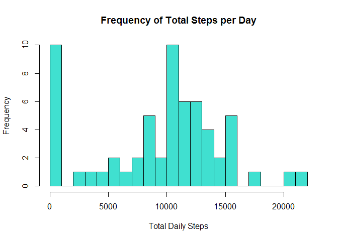

```r
hist(day_steps$total, breaks=30,
     main = "Frequency of Total Steps per Day", xlab = "Total Daily Steps",
     xlim=c(0,22000), ylim = c(0,10), col = "turquoise")
```

3. Calculate and report the mean and median of the total number of steps taken per day

```r
mean_steps <- mean(day_steps$total)
med_steps <- median(day_steps$total)
```

```r
mean_steps
```

```
## [1] 9354.23
```

```r
med_steps
```

```
## [1] 10395
```

## What is the average daily activity pattern?

1. Make a time series plot (i.e. type = “l”) of the 5-minute interval (x-axis) and the average number of steps taken, averaged across all days (y-axis)

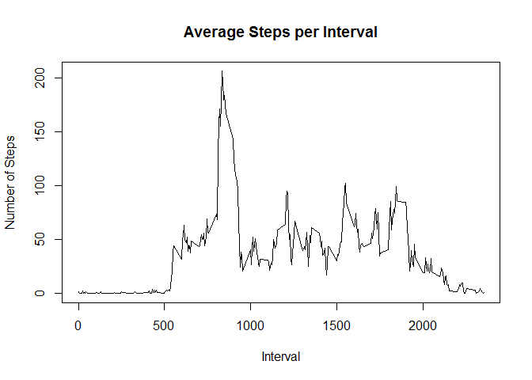

```r
interval_steps <- activity %>% group_by(interval) %>% summarise(mean_int=mean(steps, na.rm=T))

plot(interval_steps$interval, interval_steps$mean_int, type = "l",
     main = "Average Steps per Interval", xlab="Interval", ylab="Number of Steps")
```

2. Which 5-minute interval, on average across all the days in the dataset, contains the maximum number of steps?

```r
which.max(interval_steps$interval)
```

[output not shown]